# 3. Bivariate Data

**bivariate data = data contained in TWO variables**

- how to summarize univariate data? = with measures of **center** and **spread** and **the shape of a distribution** with words such as **symmetric** and **long tailed**
- with bivariate data = we can ask additional questions about the **relationship** between the two variables.

## 3.1 Pairs of categorical variables

### 3.1.1 Making two-way tables from summarized data

Use **rbind(), cbind(), or matrix()** function

```r
rbind(c(56,8), c(2,16)) ## bind rows
```

| 56 | 8 |
| --- | --- |
| 2 | 16 |

```r
cbind(c(56, 2), c(8, 16)) ## bind columns
```

| 56 | 8 |
| --- | --- |
| 2 | 16 |

```r
x <- matrix(c(56,2,8,16), nrow=2)
x
```

| 56 | 8 |
| --- | --- |
| 2 | 16 |

```r
## 56 = column 1, 2 = column 2, 8 = column 1, 16 = column 2
x <- matrix(c(56, 2, 8, 16), nrow=2, byrow=F)
x
```

[output not shown]

```r
rownames(x) <- c("buckled", "unbuckled")
x
```

| buckled | 56 | 8 |
| --- | --- | --- |
| unbuckled | 2 | 16 |

```r
colnames(x) <- c("buckled", "unbuckled")
x
```

|  | buckled | unbuckled |
| --- | --- | --- |
| buckled | 56 | 8 |
| unbuckled | 2 | 16 |

```r
tmp <- c("unbuckled", "buckled")
dimnames(x) <- list(parent=tmp, child=tmp)
x
```

|  | unbuckled | buckled |
| --- | --- | --- |
| unbuckled | 56 | 8 |
| buckled | 2 | 16 |

### 3.1.2 Making two-way tables from unsummarized data

```r
# example 3.1
library(UsingR)
```

```r
with(grades, table(prev, grade))
```

```
      grade
prev    A    A-   B+   B    B-   C+   C    D    F
   A     15    3    1    4    0    0    3    2    0
   A-     3    1    1    0    0    0    0    0    0
   B+     0    2    2    1    2    0    0    1    1
   B      0    1    1    4    3    1    3    0    2
   B-     0    1    0    2    0    0    1    0    0
   C+     1    1    0    0    0    0    1    0    0
   C      1    0    0    1    1    3    5    9    7
   D      0    0    0    1    0    0    4    3    1
   F      1    0    0    1    1    1    3    4   11
```

### 3.1.3 Marginal distributions of two-way tables

**marginal distribution** = the distribution of each **variable** seperately

- The marginal distributions can be found from the table by **summing down the rows or columns**

Use **apply()** function to apply the sum() function to the rows or the columns.

apply(x, 1, sum) <- sum the rows

apply(x, 2, sum) <- sum the columns

Use **margin.table()** function as well.

margin.table(x, 1) <- row sum

margin.table(x, 2) <- column sum

```r
margin.table(x,1)
```

**unbuckled**

64

**buckled**

18

```r
margin.table(x,2)
```

**unbuckled**

58

**buckled**

24

```r
# addmargins()

addmargins(x)
```

|  | unbuckled | buckled | Sum |
| --- | --- | --- | --- |
| unbuckled | 56 | 8 | 64 |
| buckled | 2 | 16 | 18 |
| Sum | 58 | 24 | 82 |

```r
t1 <-with(grades, table(prev, grade))

margin.table(t1,1)
```

```
prev
 A    A-   B+   B    B-   C+   C    D    F
  28    5    9   15    4    3   27    9   22
```

```r
margin.table(t1, 2)
```

```
grade
 A    A-   B+   B    B-   C+   C    D    F
  21    9    5   14    7    5   20   19   22
```

```r
apply(t1, 1, sum)
```

**A**

28

**A-**

5

**B+**

9

**B**

15

**B-**

4

**C+**

3

**C**

27

**D**

9

**F**

22

```r
apply(t1, 2, sum)
```

**A**

21

**A-**

9

**B+**

5

**B**

14

**B-**

7

**C+**

5

**C**

20

**D**

19

**F**

22

### 3.1.4 Conditional distributions of two-way tables

Let's compare the various rows of a two-way table.

```r
prop.table(x, 1) # 1 = row, 2 = column
```

|  | unbuckled | buckled |
| --- | --- | --- |
| unbuckled | 0.8750000 | 0.1250000 |
| buckled | 0.1111111 | 0.8888889 |

```r
prop <- function(x)
    {
    x / sum(x)
}
apply(x, 1, prop)
```

[output not shown]

```r
options("digits"=1)
prop.table(t1, 1)
```

```
      grade
prev    A    A-   B+   B    B-   C+   C    D    F
   A   0.54 0.11 0.04 0.14 0.00 0.00 0.11 0.07 0.00
   A-  0.60 0.20 0.20 0.00 0.00 0.00 0.00 0.00 0.00
   B+  0.00 0.22 0.22 0.11 0.22 0.00 0.00 0.11 0.11
   B   0.00 0.07 0.07 0.27 0.20 0.07 0.20 0.00 0.13
   B-  0.00 0.25 0.00 0.50 0.00 0.00 0.25 0.00 0.00
   C+  0.33 0.33 0.00 0.00 0.00 0.00 0.33 0.00 0.00
   C   0.04 0.00 0.00 0.04 0.04 0.11 0.19 0.33 0.26
   D   0.00 0.00 0.00 0.11 0.00 0.00 0.44 0.33 0.11
   F   0.05 0.00 0.00 0.05 0.05 0.05 0.14 0.18 0.50
```

### 3.1.5 Graphical summaries of two-way contingency tables

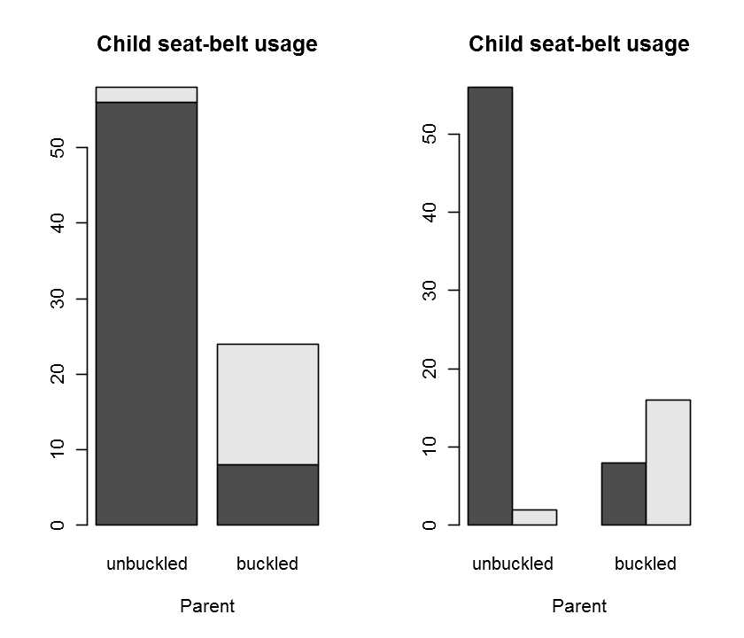

```r
# "beside" argument makes the bars to be placed side-by-side
par(mfrow=c(1,2))
options(repr.plot.height=6)
barplot(x, xlab="Parent", main="Child seat-belt usage")
barplot(x, xlab="Parent", main="Child seat-belt usage", beside=TRUE)
```

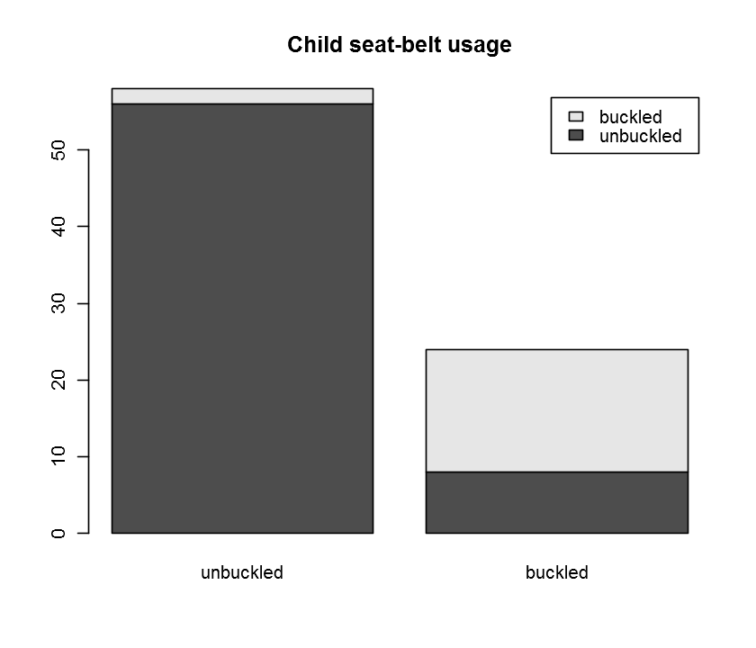

```r
# add a legend
options(repr.plot.height=6)
barplot(x, main="Child seat-belt usage", legend.text=TRUE)
```

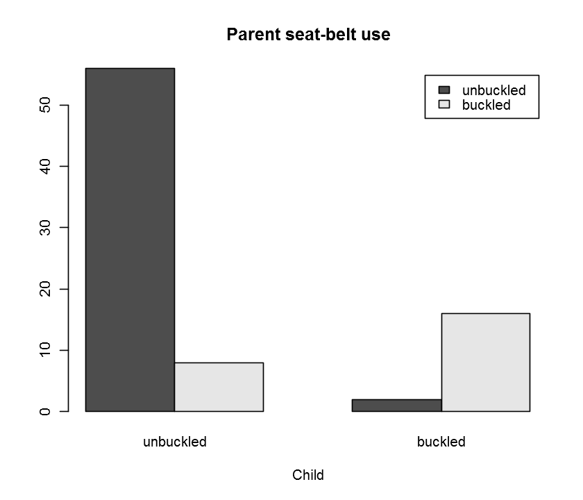

```r
options(repr.plot.height=6)
barplot(t(x), main = "Parent seat-belt use",xlab="Child", beside=TRUE, legend.text=TRUE)
```

## 3.2 Comparing independent samples

### 3.2.1 Side-by-side boxplots

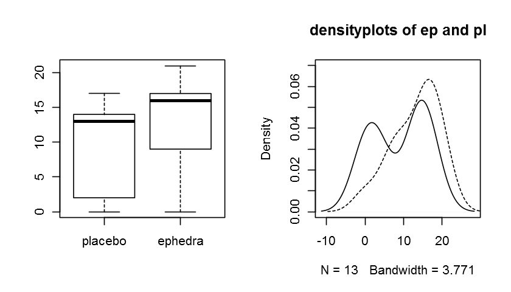

```r
par(mfrow=c(1,2))
options(repr.plot.height=4)
pl <- c(0,0,0,2,4,5,14,14,14,13,17,17,15)
ep <- c(0,6,7,9,11,13,16,16,16,17,18,20,21)
boxplot(pl, ep, names=c("placebo", "ephedra"))
plot(density(pl), ylim=c(0,0.07), main="densityplots of ep and pl")
lines(density(ep), lty=2)
```

### 3.2.3 Strip charts

first combine the data vectors into a list with list() function.

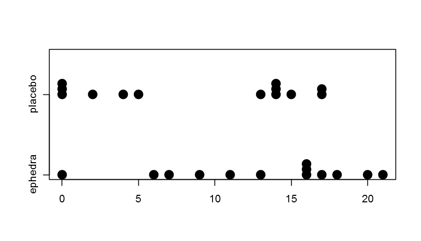

```r
stripchart(list(ephedra=ep, placebo=pl),
           method="stack", pch=16, offset=1/2, cex=2)
```

**quantile-quantile plot (q-q plot)** plots the quantiles of one distribution against the quantiles of another as points

If the distributions have similar shapes, the points will fall roughly along a **straight line**.

**A normal quantile plot** plots the quantiles of a data set against the quantiles of a benchmark distribution(= the normal distribution)

## 3.3 Relationships in numeric data

### 3.3.1 Using scatterplots to investigate relationships

**A scatterplot** is a good place to start

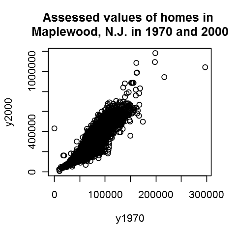

```r
# Example 3.2 Home values
# Were the homes that had been expensive in 1970 still expensive in 2000?
# The data set 'homedata' has been updated... results may be different from
# those in the book.
options(repr.plot.width=4, repr.plot.height=4)
with(homedata, plot(y1970, y2000,
                    main = "Assessed values of homes in \nMaplewood, N.J. in 1970 and 2000"))
```

```r
options(digits=4)
# The mean and the medain are not much different
summary(homedata$y1970)
```

```
   Min. 1st Qu.  Median    Mean 3rd Qu.    Max.
      0   57000   68900   70800   80500  297000
```

```r
# The mean and median differ by 16,000
summary(homedata$y2000)
```

```
   Min. 1st Qu.  Median    Mean 3rd Qu.    Max.
   7400  161000  252000  268000  336000 1180000
```

```r
summary(homedata$y2000/homedata$y1970)
```

```
   Min. 1st Qu.  Median    Mean 3rd Qu.    Max.
  0.740   2.878   3.579     Inf   4.310     Inf
```

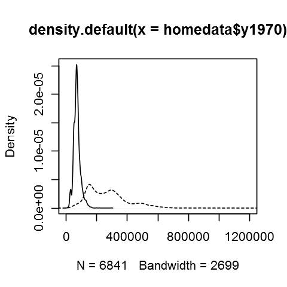

```r
plot(density(homedata$y1970), xlim=c(0,1200000))
lines(density(homedata$y2000), lty=2)
```

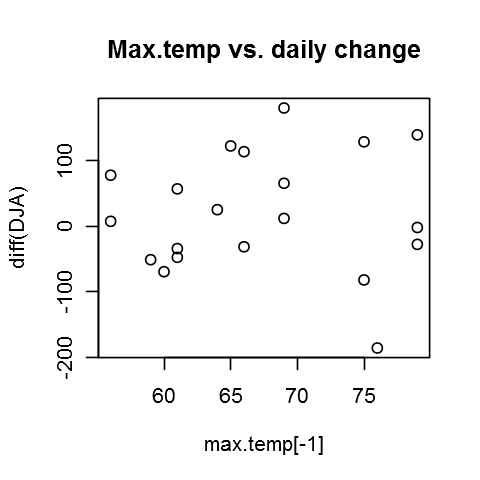

```r
# Example 3.3 A relationship between maximum temperature and the stock market
# No apparent trend = weather does not predict the stock market.

attach(maydow)
# negative indexing = excluding the corresponding value
plot(max.temp[-1], diff(DJA), main="Max.temp vs. daily change")
detach(maydow)
```

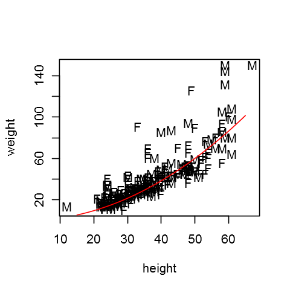

```r
# Example 3.4 Kids' weights
# BMI = weight/height^2
# The plot shows a quadratic relationship between the weights and the heights

with(kid.weights, plot(height, weight, pch=as.character(gender)))
lines(15:65, 0.024*(15:65)^2, col='red')
```

### 3.3.2 The correlation between two variables

The **correlation** between two variables numerically describes whether larger/smaller than average values of one variable are related to larger/smaller than average values of the other variable.

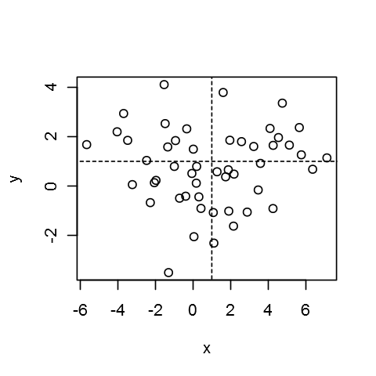

```r
# Uncorrelated data sets
x <- rnorm(50, mean=1, sd=3)
y <- rnorm(50, mean=1, sd=1.5)
plot(x,y)
lines(c(1,1), c(-4,5), lty=2)
lines(c(-6,8),c(1,1),lty=2)
```

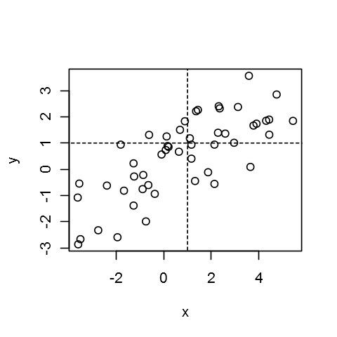

```r
x <- rnorm(50, mean=1, sd=3)
y <- 0.5*x+rnorm(50, mean=0, sd=1)
plot(x,y)
lines(c(1,1), c(-5,5), lty=2)
lines(c(-6,8),c(1,1),lty=2)
```

The upper plot is weakly correlated, or nearly uncorrelated.

For the correlated data, the products $(x_i-\bar{x})(y_i-\bar{y})$ will tend to be positive, as this happens in both the upper-right and lower-left quadrants.

This is not the case for the uncorrelated data.

The quantity $\sum_{i}(x_i-\bar{x})(y_i-\bar{y})$ will be useful in describing the correlation between two variables.

To produce a numeric summary that can be used to compare data sets, this sum is scaled by a term related to the product of the sample standard deviations. With this scaling, the correlation only involves the respective z-scores, and the quantity is always between -1 and 1.

```
                    The Pearson correlation coefficient
```

$$r = cor(x,y) = \frac{\sum(x_i-\bar{x})(y_i-\bar{y})}{\sqrt{\sum(x_i-\bar{x})^2\sum(y_i-\bar{y})^2}} = \frac{1}{n-1}\sum(\frac{x_i-\bar{x}}{s_x})(\frac{y_i-\bar{y}}{s_y})$$

$s_x$ = standard deviation of a data vector x

$s_y$ = standard deviation of a data vector y

```r
attach(homedata);attach(maydow);attach(kid.weights)

# cor() shows the correlation between two variables(method = Pearson's r)
cor(y1970, y2000)
cor(max.temp[-1], diff(DJA))

# doubtful about a linear relationship
cor(height, weight)
```

0.896215487264815

0.0102884615164777

0.823756369960437

**The Spearman rank correlation**

If the relationship between the variables is **not linear** but is increasing, we can still use the correlation coefficient.

The Spearman rank correlation is the Pearson correlation coefficient computed with the ranked data.

http://m.blog.naver.com/istech7/50153288534#

```r
x <- c(30, 20, 7, 42, 50, 20)
# ties are averaged
sort(x, decreasing=FALSE)
y <- c(24, 3, 11, 5, 29, 34)
sort(y, decreasing=FALSE)

cor(x,y)
cor(x,y, method="spearman")
```

1. 7

2. 20

3. 20

4. 30

5. 42

6. 50

1. 3

2. 5

3. 11

4. 24

5. 29

6. 34

0.204152007367257

0.173931310695735

```r
## homedata example, r = 0.8962
cor(rank(y1970), rank(y2000))

## Dow Jones example, r = 0.01029
cor(max.temp[-1], diff(DJA), method="spearman")

## height and weight example, r = 0.8238
## The spearman's correlation coefficient is higher than that of pearson's
cor(height, weight, m="s")

detach(homedata);detach(maydow);detach(kid.weights)
```

0.887818497735853

0.131571113863847

0.882213632978232

## 3.4 Simple linear regression

**regression**

https://ko.wikipedia.org/wiki/%ED%9A%8C%EA%B7%80%EB%B6%84%EC%84%9D

We say that variables $x$ and $y$ have a linear relationship in *a mathematical sense* we mean that $y = mx+b$, where $m$ is the **slope** of the line and $b$ the **intercept**. We call $x$ the **independent variable** and $y$ the **dependent** one.

In statistics, we don't assume these variables have an exact linear relationship: rather, the possibility for noise or error is taken into account.

**Simple Linear Regression Model**

$y_i = \beta_0 + \beta_1x_i + \epsilon_i$

$\epsilon_i$ = **error term** (unknown)

$\beta_0, \beta_1$ = **regression coefficients** (unknown)

$x$ = **predictor variable**

$y$ = **response variable**

The term **linear** is about the way the regression coefficients are used.

$y_i = \beta_0 + \beta_1x_i^2 + \epsilon_i$ is a **linear** model

$y_i = \beta_0 + \beta_1\beta_2x_i + \epsilon_i$ is a **non-linear(quadratic)** model

The term **simple** is used to emphasize that only one predictor variable is used. In **multiple** regression models, more than one predictor variables are used.

Through a **model**, we estimate the **coefficients** that yield estimated response variables closest to the actual response variables. "Hats" denote the estimates.

$$\hat{y} = \hat{\beta_0} + \hat{\beta_1}x$$

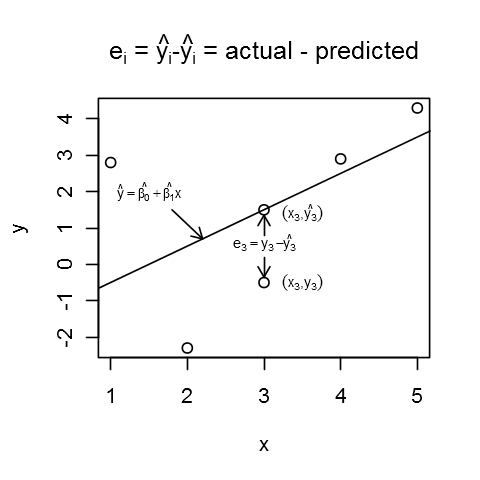

```r
x <- c(1,2,3,3,4,5)
y <- c(2.8, -2.3, -0.5, 1.5,2.9, 4.3)
plot(x,y, main=bquote(e[i]*" = "* hat(y[i])*"-"*hat(y[i])*" = actual - predicted"))
lines(0.5:5.5, 0.5:5.5-1.5)
text(1.5,2,expression(hat(y) == paste(hat(beta[0]) + hat(beta[1]))*"x"), cex=0.7)
text(3.5, -0.5, expression((paste(x[3],",",y[3]))), cex=0.7)
text(3.5, 1.4, expression((paste(x[3],",",hat(y[3])))), cex=0.7)
text(3, 0.6, expression(e[3] == paste(y[3]-hat(y[3]))), cex=0.7)
arrows(3,0.8,3,1.35, length=0.1)
arrows(3, 0.2, 3, -0.35, length=0.1)
arrows(1.8, 1.5, 2.2, 0.7, length=0.1)
```

Geometrically, the residual is the signed vertical distance of the point ($x_i, y_i$) to the prediction line as seen in the figure above. If the estimated line is a good one, these distances should be small.

The **method of least squares** chooses the line so that the sum of the *squared* residuals is *as small as* possible.

$$\hat{\beta_1} = \frac{\sum(x_i-\bar{x})(y_i-\bar{y})}{\sum(x_i-\bar{x})^2}$$$$\hat{\beta_0} = \bar{y} - \hat{\beta_1}\bar{x}$$

Interpreting, the regression line goes through the point ($\bar{x}, \bar{y}$) and has slope given by $\hat{\beta_1}$

### 3.4.1 Using the regression model for prediction.

One of the primary uses of simple linear regression is to make predictions for the response value for new values of the predictor.

### 3.4.2 Finding the regression coefficients using lm()

lm(model.formula) function for linear models.

formula notation: y~x.

~ is read "is modeled by,"

The formula implicitly assumes an intercept term and a linear model.

```r
# Example 3.5 The regression line for the Maple wood home data
attach(homedata)
fit1 <- lm(y2000~y1970)
fit1
```

```
Call:
lm(formula = y2000 ~ y1970)

Coefficients:
(Intercept)        y1970
 -1.040e+05    5.258e+00
```

```r
sxy <- sum((y1970-mean(y1970))*(y2000-mean(y2000)))
sx2 <- sum((y1970-mean(y1970))^2)
# hat(beta_1)
sxy/sx2
# hat(beta_0)
# The negative intercept should be a warning not to use this model for prediction
# with a really low 1970 home value.
mean(y2000) - sxy/sx2 * mean(y1970)
```

5.25797223638517

-104004.712310672

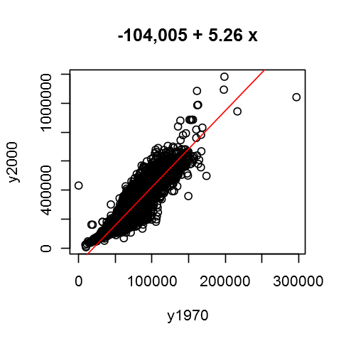

```r
plot(y1970, y2000, main="-104,005 + 5.26 x")
# Adding a regression line to the scatterplot
abline(fit1, col="red")
```

```r
# Using the regression line for predictions
# Let's find the y-2000 predicted value of a house worth $50,000 in 1970

-104005+5.26*50000
```

158995

```r
# use coef() to extract coefficients of a linear regression model
betas <- coef(fit1)
sum(betas*c(1, 50000))
```

158893.899508588

```r
# predict()
x <- 1:10
y <- 4*x + rnorm(10)
fit2 <- lm(y~x)
predict(fit2, data.frame(x=3))
```

[output not shown]

```r
# residual
y[x==3] - predict(fit2, data.frame(x=3))
```

**1:** -0.527628426557511

```r
# residuals()
residuals(fit2)[x==3]
residuals(fit2)[which(x==3 & y==y[x==3])]
```

**3:** -0.527628426557509

**3:** -0.527628426557509

```r
y2000[y1970 == 55100]
```

1. 142000

2. 153800

3. 157300

4. 184900

5. 162900

6. 151800

7. 145200

8. 130200

```r
predict(fit1, data.frame(y1970=55100))
```

**1:** 185709.557914153

```r
184900 - predict(fit1, data.frame(y1970=55100))
```

**1:** -809.557914152509

```r
residuals(fit1)[which(y1970==55100 & y2000 == 184900)]
```

**3483:** -809.557914151118

```r
detach(homedata)
```

The model formula offers some additional flexibility

The argument **data=** can usually be used to attach a *data frame* temporarily. This provides an environment where R can **reference the variables within a data frame by their name**, avoiding the trouble of attaching and detaching the data frame.

The argument **subset=** can be used to restrict the rows that are used in the data.

### 3.4.3 Transformations of the data

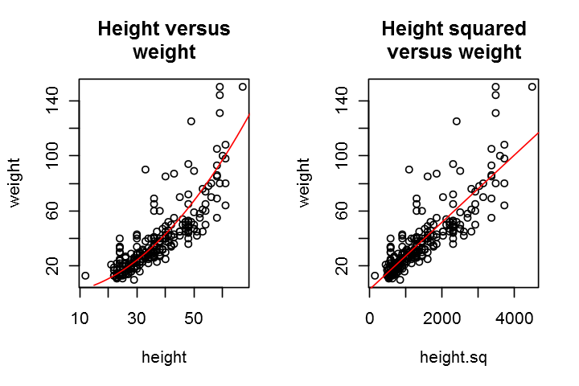

```r
# Example 3.6

par(mfrow=c(1,2))
options(repr.plot.width = 6)

with(kid.weights, plot(height, weight,
                      cex=0.8, main = "Height versus\nweight"))
lines(15:70, 0.027*(15:70)^2, col='red')

# This shows a better fit with a linear model than before.
height.sq <- kid.weights$height^2
plot(weight~height.sq, data=kid.weights, main="Height squared\nversus weight",
    cex=0.8)
res <- lm(weight~height.sq, data=kid.weights)
abline(res, col="red")
```

```r
# shows the coefficients of the model with the squared heights
res
```

```
Call:
lm(formula = weight ~ height.sq, data = kid.weights)

Coefficients:
(Intercept)    height.sq
    3.10894      0.02436
```

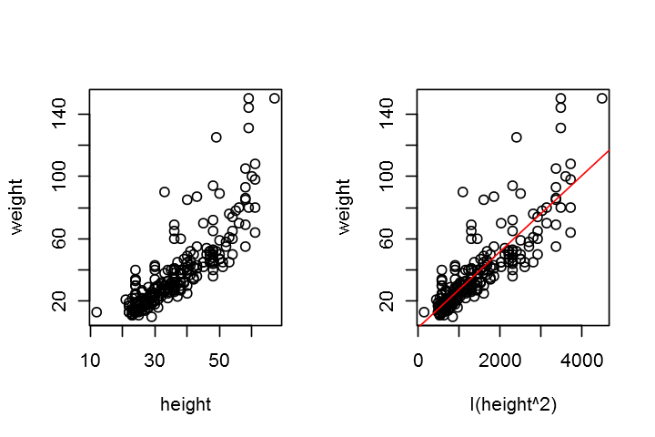

```r
# Transformation within the plot function does not reflect the transformation.
par(mfrow=c(1,2))
options(repr.plot.width = 6)
plot(weight~height^2, data=kid.weights)

# Use I() function
plot(weight~I(height^2), data=kid.weights)
res <- lm(weight~I(height^2), data=kid.weights)
abline(res, col="red")
```

### 3.4.4 Interacting with a scatterplot

- identify(): identify points on a scatterplot by their corresponding index
- locator(): locate the (x,y) coordinates of the points we select with our mouse.

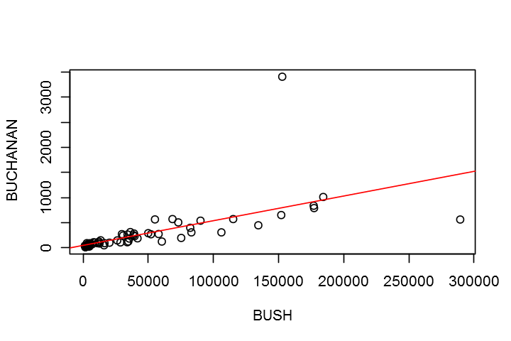

```r
# Example 3.7 Florida 2000 (Show it in R)

plot(BUCHANAN ~ BUSH, data=florida)
res <- lm(BUCHANAN ~ BUSH, data=florida)
abline(res, col="red")
with(florida, identify(BUSH, BUCHANAN, n=2, labels=County))
```

```r
# PALM BEACH
with(florida, predict(res, data.frame(BUSH=BUSH[50])))
residuals(res)[50]
```

**1:** 796.807370315355

**50:** 2610.19262968464

### 3.4.5 Outliers in the regression model

Two types of outliers

- in the univariate sense = a data point that doesn't fit the pattern set by the bulk of the data
- in the regression model = points that are far from the trend or pattern of the data

```r
f <- CO2~perCapita
```

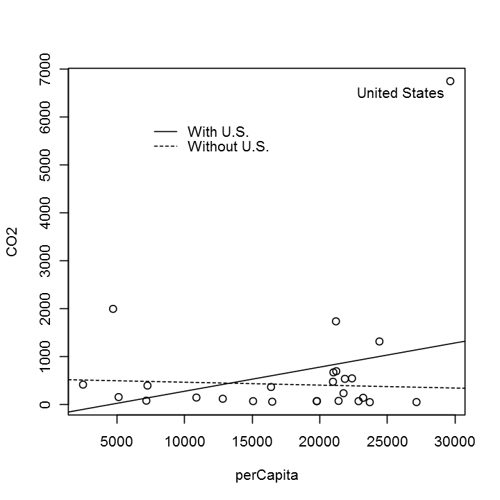

```r
options(repr.plot.width = 6, repr.plot.height=6)
plot(f, data=emissions)
abline(lm(CO2~perCapita, data=emissions))
abline(lm(f, data=emissions, subset=-1), lty=2)
legend(7000, 6000, c("With U.S.", "Without U.S."), bty='n', lty=c(1,2))
text(26000, 6500, "United States")
```

'United States' is an outlier for the CO2 variable, but not for the per-capita GDP  
-> an outlier in **the bivariate sense**, as it stands far off from the trend set by the rest of the data

### 3.4.6 Resistant regression lines: lqs() and rlm()

regression coefficients are subject to strong influences from outliers.

- Alternatives to the mean and standard deviation -> median or the IQR

There are several resistant alternatives for the regression line.

1) Least-trimmed squares  
The least-squares regression line is found conceptually by calculating for each line *the sum of the squared residuals* and then minimizing this value over all possible lines.  
Least trimmed squares does the same, only the sum of the squared residuals is replaced by the sum of the $q$ smallest squared residuals, where $q$ is roughly $\frac{n}{2}$.  
The least-trimmed squares algorithm is implemented in the lqs() function from the MASS package.

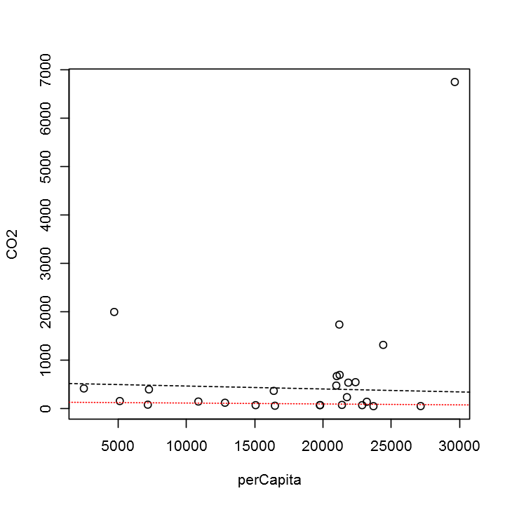

```r
# library(MASS)
plot(f, data=emissions)
abline(lm(f, data=emissions, subset=-1), lty=2)
abline(lqs(f, data=emissions), lty=3, col="red")
```

2) Resistant regression using rlm()

It is not as resistant to outliers as lqs() by default, but can be made so with the method = "MM".

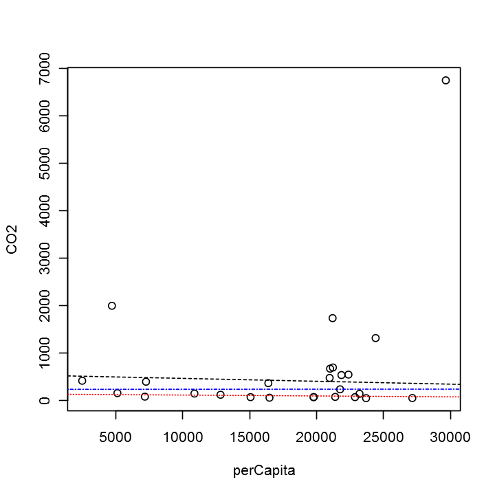

```r
# library(MASS)
plot(f, data=emissions)
abline(lm(f, data=emissions, subset=-1), lty=2)
abline(lqs(f, data=emissions), lty=3, col="red")
abline(rlm(f, data=emissions, method="MM"), lty=4, col="blue")
```

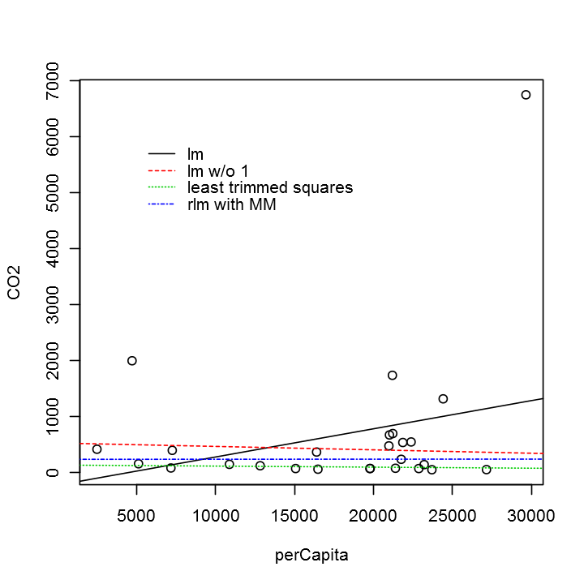

```r
plot(f, data=emissions)
abline(lm(CO2~perCapita, data=emissions))
abline(lm(f, data=emissions, subset=-1), lty=2, col=2)
abline(lqs(f, data=emissions), lty=3, col=3)
abline(rlm(f, data=emissions, method="MM"), lty=4, col=4)
the.labels <- c("lm", "lm w/o 1", "least trimmed squares", "rlm with MM")
the.ltys <- 1:4
the.cols <- 1:4
legend(5000, 6000, legend=the.labels, lty=the.ltys, col=the.cols, bty="n")
```

### 3.4.7 Trend lines

If a scatterplot suggests some relationship, but not an obvious transformation to make a linear relationship, we can still superimpose a "trend line" on top of the data using one of the many scatterplot smoothing techniques available in R.

- **scatter.smooth()**: uses the loess() function
- **smooth.spline()**: cubinc splines
- **supsmu()**: Friedman's "super smoother" algorithm

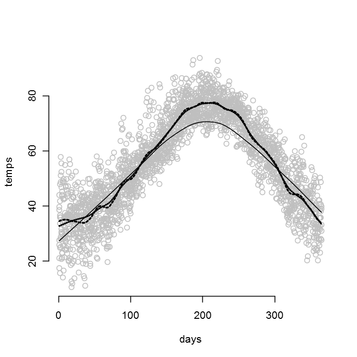

```r
# Example 3.9

attach(five.yr.temperature)
# bty="n" means no background
scatter.smooth(temps~days, col=gray(.75), bty="n")
# lty = line type, lwd = line width
lines(smooth.spline(temps ~ days), lty=2, lwd=2)
lines(supsmu(days, temps), lty=3, lwd=2)
# locator(): Reads the position of the graphics cursor
# when the (first) mouse button is pressed (Show this in R)
# legend(locator(1), lty=c(1,2,3), lwd=c(1,2,2),
#       legend=c("scatter.smooth", "smooth.spline", "supsmu"))
detach(five.yr.temperature)
```